# First T-FLASH Fit of GTEX Data

David Gerard

2016-04-05

## Abstract

I give a first pass at fitting T-FLASH on the GTEX data. I find some interpretable factors. But I also find that I’m mostly interpreting results in terms of tissue and gene factors, and not the individual factors. I wonder if treating samples as independent observations would be more appropriate.

```r
library(xtable)
library(flashr)
library(ggplot2)
data_path <- "~/Data/gtex/v6_gene_reads/"
load(file = paste0(data_path, "gtex_array_1000.Rdata"))
subject_pheno <- read.table(paste0(data_path,
                                   "GTEx_Data_V6_Annotations_SubjectPhenotypesDS.txt"),
                            header = TRUE)

get_subid <- function(x) {
  y <- strsplit(x, split = "-")[[1]]
  return(y[2])
}
subid <- sapply(subject_pheno$SUBJID, get_subid)
subject_pheno$subid <- subid
subid_order <- match(dimnames(gtex_array)[[2]], subid)
subject_pheno <- subject_pheno[subid_order, ]

plot_pheno <- function(factor_list, subject_pheno, k) {
  t1 <- qplot(x = Gender, y = Factor,
       data = data.frame(Factor = factor_list[[2]][, k],
                         Gender = as.factor(subject_pheno$GENDER)),
        geom = "boxplot", fill = I("skyblue"), xlab = "Gender",
        main = paste0("Factor ", k, " vs Gender"))
  t2 <- qplot(x = Age, y = Factor,
        data = data.frame(Factor = factor_list[[2]][, k],
                          Age = as.factor(subject_pheno$AGE)),
        geom = "boxplot", fill = I("skyblue"), xlab = "Age",
        main = paste0("Factor ", k, " vs Age"))
  t3 <- qplot(x = DTHHRDY, y = Factor,
        data = data.frame(Factor = factor_list[[2]][, k],
                          DTHHRDY = as.factor(subject_pheno$DTHHRDY)),
        geom = "boxplot", fill = I("skyblue"), xlab = "DTHHRDY",
        main = paste0("Factor ", k, " vs DTHHRDY"))
  print(t1)
  print(t2)
  print(t3)
}
```

## GTEX Data Munging Summary

I only looked at tissues that had at least 20 samples, excluding brain tissues and any sex-dependent tissues (Vagina, Testis, Uterus, Prostate, and Ovary).

For each gene, I calculated the following score:

1. Normalize by log(counts + 1),
2. Take the average within each of the saved tissues,
3. Take the max of the averages and set this to be the gene’s score.

The genes with the top 1000 scores were then saved. The intuition behind this is that genes that are highly expressed within only a couple tissues will still make it into the dataset.

Taking the dataset with only the top 1000 genes, I then normalized each sample by taking log(counts + 1) then subtracting off the 75th percentile.

Expression data from samples of the same individual/tissue combination were then averaged together.

Finally, I only kept subjects that had at least 5 tissues samples. The final data array had dimensions (1000, 496, 21), where the dimensions are genes by individuals by tissues. The proportion of observations that were missing in this dataset was 0.5074. These are structured missing values and not sampled independently, where most individuals are missing whole tissues. If the mean actually is low cp-rank, I don’t think this is a big deal as long as these tissues are missing at random.

## Fit T-FLASH

I calculate the first ten factors from greedy T-FALSH.

```r
tout <- tgreedy(gtex_array, nullweight = 10, k = 10)
```

The residual plots actually look pretty good. Plotting the residuals against the mean estimates looks like a perfect example of a good residual plot. Plotting the observed values against the residuals one observes a small increasing trend in the residuals for larger observed values. Overall, I’m pretty happy with these residual plots.

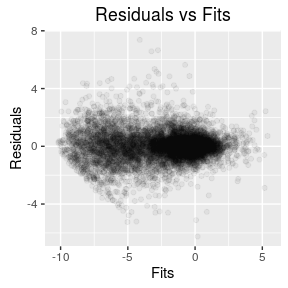

```r
mean_est <- form_mean(tout$factor_list)
resids <- gtex_array - mean_est

p <- dim(gtex_array)
sample_points <- sample(1:prod(p), size = 20000)
qplot(mean_est[sample_points], resids[sample_points], alpha = I(0.05), xlab = "Fits",
      ylab = "Residuals", main = "Residuals vs Fits")
```

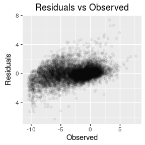

```r
qplot(gtex_array[sample_points], resids[sample_points], alpha = I(0.05), xlab = "Observed",
      ylab = "Residuals", main = "Residuals vs Observed")
```

### First Factor

The first factors are just picking up the overall mean. I calculate the mean within each factor level for each dimension and plot these against each dimension’s first component and get very strong relationships.

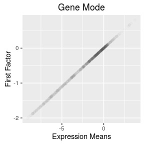

```r
expression_levels_bygene <- apply(gtex_array, 1, mean, na.rm = TRUE)
qplot(expression_levels_bygene, tout$factor_list[[1]][, 1], xlab = "Expression Means",
      ylab = "First Factor", main = "Gene Mode", alpha = I(0.01))
```

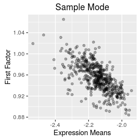

```r
expression_levels_bysamp <- apply(gtex_array, 2, mean, na.rm = TRUE)
qplot(expression_levels_bysamp, tout$factor_list[[2]][, 1], xlab = "Expression Means",
      ylab = "First Factor", main = "Sample Mode", alpha= I(0.3))
```

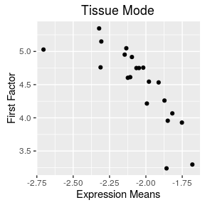

```r
expression_levels_bytiss <- apply(gtex_array, 3, mean, na.rm = TRUE)
qplot(expression_levels_bytiss, tout$factor_list[[3]][, 1], xlab = "Expression Means",
      ylab = "First Factor", main = "Tissue Mode")
```

### Second Factor

The second factor loads very heavily (negatively under the current parameterization) on Muscle and Heart and moderately or postively on everyother tissue:

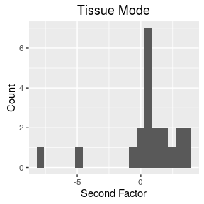

```r
qplot(tout$factor_list[[3]][, 2], geom = "histogram", bins = 20, ylab = "Count",
      xlab = "Second Factor", main = "Tissue Mode")
```

```r
factor2_order <- order(tout$factor_list[[3]][, 2])
print(xtable(data.frame(Tissue = dimnames(gtex_array)$tissues[factor2_order],
                        Factor2 = tout$factor_list[[3]][, 2][factor2_order]),
             digits = 1),
      include.rownames = FALSE, type = "html")
```

| Tissue | Factor2 |
| --- | --- |
| Muscle | -7.7 |
| Heart | -4.9 |
| Blood Vessel | -0.9 |
| Nerve | -0.1 |
| Adipose Tissue | 0.2 |
| Esophagus | 0.3 |
| Pituitary | 0.7 |
| Skin | 0.7 |
| Colon | 0.7 |
| Breast | 0.8 |
| Thyroid | 0.8 |
| Salivary Gland | 0.8 |
| Kidney | 1.2 |
| Adrenal Gland | 1.4 |
| Stomach | 1.6 |
| Lung | 1.7 |
| Small Intestine | 2.3 |
| Pancreas | 3.1 |
| Spleen | 3.2 |
| Liver | 3.8 |
| Blood | 3.9 |

The second factor loads positively for all individuals:

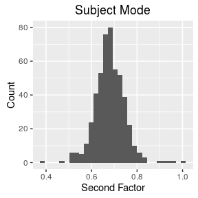

```r
qplot(tout$factor_list[[2]][, 2], bins = 30, ylab = "Count",
      xlab = "Second Factor", main = "Subject Mode")
```

The genes are moderately loaded on the second factor for most genes but have a strong left tail.

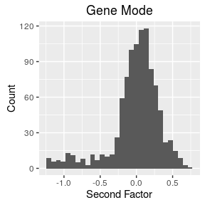

```r
qplot(tout$factor_list[[1]][, 2], bins = 30, ylab = "Count",
      xlab = "Second Factor", main = "Gene Mode")
```

The interpretation is that these genes in the left tail are “muscle” and “heart” genes. For example, take the ten most heavily loaded genes:

```r
gene_f2_order <- order(tout$factor_list[[1]][, 2])
top_ten_genes <- data.frame(Gene = dimnames(gtex_array)[[1]][gene_f2_order][1:10],
                            Factor2 = tout$factor_list[[1]][, 2][gene_f2_order][1:10])
print(xtable(top_ten_genes), include.rownames = FALSE, type = "html")
```

| Gene | Factor2 |
| --- | --- |
| ENSG00000104879.4 | -1.24 |
| ENSG00000186439.8 | -1.24 |
| ENSG00000197893.9 | -1.24 |
| ENSG00000198125.8 | -1.23 |
| ENSG00000170807.11 | -1.21 |
| ENSG00000258444.1 | -1.20 |
| ENSG00000143632.10 | -1.20 |
| ENSG00000092054.12 | -1.19 |
| ENSG00000163092.15 | -1.19 |
| ENSG00000111245.10 | -1.18 |

- ENSG00000104879 is [creatine kinase](https://en.wikipedia.org/wiki/Creatine_kinase) which consumes ATP and is used especially in skeletal muscle.
- ENSG00000186439 is [triadin](https://en.wikipedia.org/wiki/Triadin) which is used in muscle contraction.
- ENSG00000197893 is [Nebulin-related-anchoring protein](https://en.wikipedia.org/wiki/NRAP) is involved in cell-cell connections in muscle.
- ENSG00000198125 is [myoglobin](https://en.wikipedia.org/wiki/Myoglobin) which is an iron and oxygen binding protein found in muscle tissue.
- ENSG00000170807 is [leiomodin 2](http://useast.ensembl.org/Homo_sapiens/Gene/Summary?db=core;g=ENSG00000170807;r=7:123655807-123664290), which is functional in the heart.
- ENSG00000258444 is [non-coding](http://useast.ensembl.org/Homo_sapiens/Gene/Summary?db=core;g=ENSG00000258444;r=14:23415339-23415686;t=ENST00000557368).
- ENSG00000143632 is [actin, alpha 1](https://en.wikipedia.org/wiki/Actin,_alpha_1), which is involved in skeletal tissue.
- ENSG00000092054 is MYH7 is primarily used in the heart, but also in skeletal muscle.
- ENSG00000163092 is XIRP2, which codes an actin-binding protein.
- ENSG00000111245 is [Myosin regulatory light chain 2, ventricular/cardiac muscle isoform](https://en.wikipedia.org/wiki/MYL2) is used in the heart.

The subject phenotypes have no major relationship with the second factor.

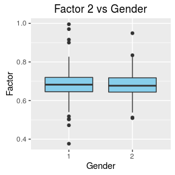

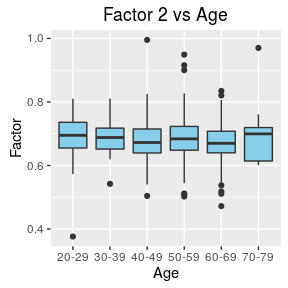

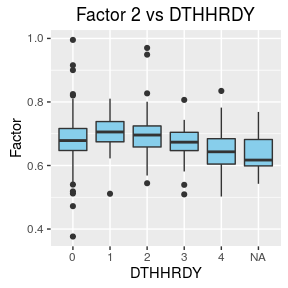

```r
plot_pheno(tout$factor_list, subject_pheno, 2)
```

### Third Factor

The third factor appears to primarily be the “blood and muscle” factor. In particular, blood is most negatively loaded whereas blood vessel is most positively loaded.

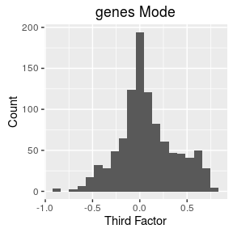

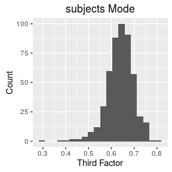

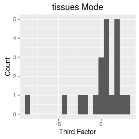

```r
for(mode_index in 1:3) {
    print(qplot(tout$factor_list[[mode_index]][, 3], xlab = "Third Factor",
            ylab = "Count", main = paste(names(dimnames(gtex_array))[mode_index], "Mode"),
            bins = 20))
}
```

```r
factor3_order <- order(tout$factor_list[[3]][, 3])
print(xtable(data.frame(Tissue = dimnames(gtex_array)$tissues[factor3_order],
                        Factor3 = tout$factor_list[[3]][, 3][factor3_order]),
             digits = 1),
      include.rownames = FALSE, type = "html")
```

| Tissue | Factor3 |
| --- | --- |
| Blood | -8.8 |
| Muscle | -4.0 |
| Spleen | -2.3 |
| Liver | -2.0 |
| Heart | -0.4 |
| Pituitary | -0.2 |
| Pancreas | -0.0 |
| Salivary Gland | -0.0 |
| Kidney | 0.3 |
| Small Intestine | 0.5 |
| Adrenal Gland | 0.5 |
| Lung | 0.6 |
| Stomach | 0.8 |
| Skin | 1.0 |
| Colon | 1.6 |
| Esophagus | 1.6 |
| Thyroid | 1.7 |
| Breast | 1.8 |
| Adipose Tissue | 1.9 |
| Nerve | 2.3 |
| Blood Vessel | 2.9 |

Subject associations:

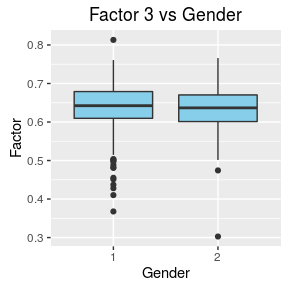

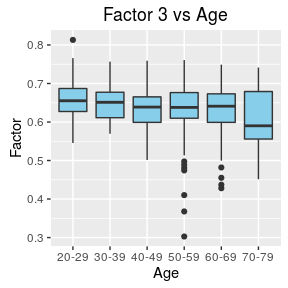

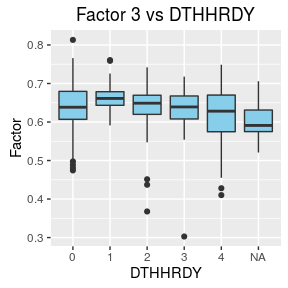

```r
plot_pheno(tout$factor_list, subject_pheno, 3)
```

### Fourth Factor

The fourth factor is the “pancreas” factor.

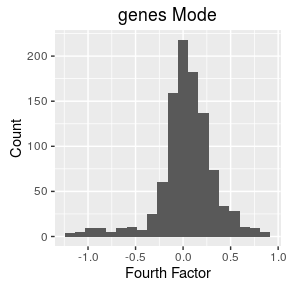

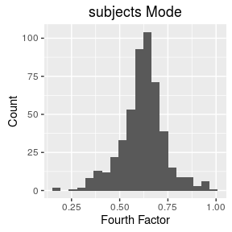

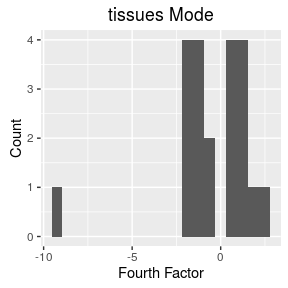

```r
for(mode_index in 1:3) {
    print(qplot(tout$factor_list[[mode_index]][, 4], xlab = "Fourth Factor",
            ylab = "Count", main = paste(names(dimnames(gtex_array))[mode_index], "Mode"),
            bins = 20))
}
```

```r
factor4_order <- order(tout$factor_list[[3]][, 4])
print(xtable(data.frame(Tissue = dimnames(gtex_array)$tissues[factor4_order],
                        Factor4 = tout$factor_list[[3]][, 4][factor4_order]),
             digits = 1),
      include.rownames = FALSE, type = "html")
```

| Tissue | Factor4 |
| --- | --- |
| Pancreas | -9.0 |
| Pituitary | -2.0 |
| Adrenal Gland | -1.9 |
| Liver | -1.8 |
| Stomach | -1.8 |
| Skin | -1.4 |
| Muscle | -1.2 |
| Kidney | -1.1 |
| Small Intestine | -0.9 |
| Colon | -0.5 |
| Esophagus | -0.3 |
| Salivary Gland | 0.3 |
| Heart | 0.5 |
| Thyroid | 0.5 |
| Breast | 0.6 |
| Blood Vessel | 1.2 |
| Nerve | 1.2 |
| Adipose Tissue | 1.5 |
| Blood | 1.5 |
| Spleen | 1.9 |
| Lung | 2.7 |

Subject associations:

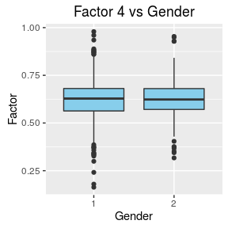

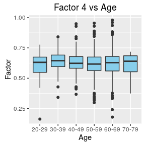

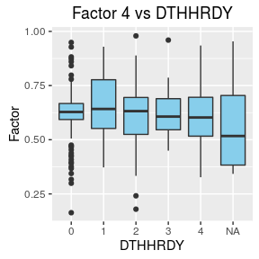

```r
plot_pheno(tout$factor_list, subject_pheno, 4)
```

### Fifth Factor

The fifth factor is the “Liver” factor.

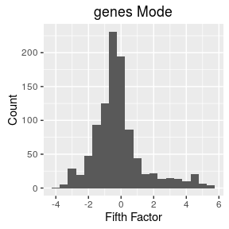

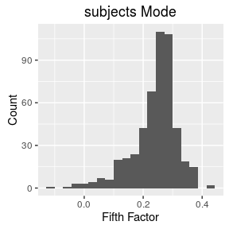

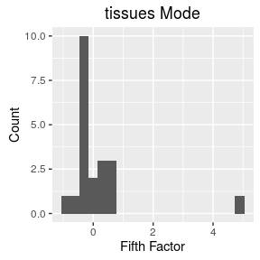

```r
for(mode_index in 1:3) {
    print(qplot(tout$factor_list[[mode_index]][, 5], xlab = "Fifth Factor",
            ylab = "Count", main = paste(names(dimnames(gtex_array))[mode_index], "Mode"),
            bins = 20))
}
```

```r
factor5_order <- order(tout$factor_list[[3]][, 5])
print(xtable(data.frame(Tissue = dimnames(gtex_array)$tissues[factor5_order],
                        Factor5 = tout$factor_list[[3]][, 5][factor5_order]),
             digits = 1),
      include.rownames = FALSE, type = "html")
```

| Tissue | Factor5 |
| --- | --- |
| Pancreas | -1.0 |
| Blood | -0.6 |
| Spleen | -0.4 |
| Small Intestine | -0.4 |
| Stomach | -0.4 |
| Colon | -0.4 |
| Heart | -0.4 |
| Pituitary | -0.3 |
| Esophagus | -0.3 |
| Lung | -0.3 |
| Salivary Gland | -0.2 |
| Thyroid | -0.2 |
| Blood Vessel | -0.1 |
| Nerve | -0.0 |
| Skin | 0.2 |
| Muscle | 0.4 |
| Breast | 0.4 |
| Adipose Tissue | 0.5 |
| Adrenal Gland | 0.5 |
| Kidney | 0.6 |
| Liver | 4.8 |

This is this first factor that seems to show an association with subject phenotype. Older people clearly load less heavily on this mode than younger people.

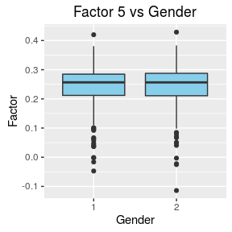

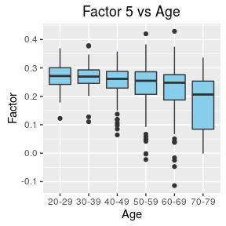

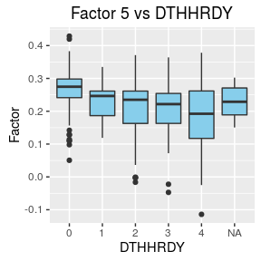

```r
plot_pheno(tout$factor_list, subject_pheno, 5)
```